# Análise da base de dados IMDb

Laila Viana de Almeida

IMDb (*Internet Movie Data Base*) é uma base de dados disponível online que compila informações sobre cinema, TV, música e jogos.

Para realizar as análises do banco de dados IMDB e responder as perguntas do relatório, a primeira coisa a se fazer foi baixar as bases através do pacote basesCursoR.

```r
imdb <- basesCursoR::pegar_base("imdb_completa")
imdb_pessoas <- basesCursoR::pegar_base("imdb_pessoas")
imdb_avaliacoes <- basesCursoR::pegar_base("imdb_avaliacoes")
```

Com as bases já baixadas no environment, carreguei os pacotes que irei utilizar nas análises. O pacote tidyverse será utilizado para manipulação geral dos dados, o lubridate para trabalhar com datas e o reactable para geração de tabelas.

```r
library(tidyverse)
library(lubridate)
library(reactable)
```

# 1. Qual o mês do ano com o maior número de filmes? E o dia do ano?

O mês do ano com maior número de filmes foi o mês de outubro, com 8734 filmes. Já o dia do ano com maior número de filmes foi o dia 1, com 7260 filmes.

```r
imdb |> filter(!is.na(data_lancamento)) |>
  mutate(data = as_date(data_lancamento),
                year = lubridate::year(data),
                month = lubridate::month(data),
                day = lubridate::day(data)) |> count(month) |>
  arrange(desc(n)) |> head(5) |>
  reactable(columns = list(
    month = colDef(name = "Mês do Ano"),
    n = colDef(name = "Número de Filmes")))
```

| Mês do Ano | Número de Filmes |
| --- | --- |
| 10 | 8734 |
| 9 | 7924 |
| 3 | 7435 |
| 11 | 7094 |
| 4 | 7078 |

```r
imdb |> filter(!is.na(data_lancamento)) |>
  mutate(data = as_date(data_lancamento),
                year = lubridate::year(data),
                month = lubridate::month(data),
                day = lubridate::day(data)) |> count(day) |>
  arrange(desc(n)) |> head(5) |> drop_na() |>
  reactable(columns = list(
    day = colDef(name = "Dia do Mês"),
    n = colDef(name = "Número de Filmes")))
```

| Dia do Mês | Número de Filmes |
| --- | --- |
| 1 | 7260 |
| 15 | 2831 |
| 14 | 2728 |
| 25 | 2727 |

# 2. Qual o top 5 países com mais filmes na base?

O top 5 países com mais filmes na base foram: USA, França, Reino Unido, India e Itália.

```r
imdb |> separate_rows(pais, sep=", ") |>
  group_by(pais) |> summarise(n = n()) |> arrange(desc(n)) |> head(5) |>
  reactable(columns = list(
    pais = colDef(name = "País"),
    n = colDef(name = "Número de Filmes")))
```

| País | Número de Filmes |
| --- | --- |
| USA | 34325 |
| France | 8311 |
| UK | 7490 |
| India | 6373 |
| Italy | 5056 |

# 3. Liste todas as moedas que aparecem nas colunas `orcamento` e `receita` da base `imdb_completa`.

Apareceram 62 tipos diferentes de moedas nas colunas orçamento e receita. Elas estão listadas abaixo.

```r
imdb |> drop_na(orcamento, receita) |> select(orcamento, receita) |>
  mutate(orcamento = str_replace(orcamento, "\\s.*$", ""),
         receita = str_replace(orcamento, "\\s.*$", "")) |> unique() |>
  reactable(columns = list(
    orcamento = colDef(name = "Moedas que aparecem em Orçamento"),
    receita = colDef(name = "Moedas que aparecem em Receita")))
```

| Moedas que aparecem em Orçamento | Moedas que aparecem em Receita |
| --- | --- |
| $ | $ |
| NOK | NOK |
| GBP | GBP |
| DEM | DEM |
| FRF | FRF |
| SEK | SEK |
| ITL | ITL |
| JPY | JPY |
| RUR | RUR |
| AUD | AUD |

[output cut: 52 more lines]

# 4. Considerando apenas orçamentos e receitas em dólar ($), qual o gênero com maior lucro? E com maior nota média?

Como eu preciso calcular o lucro algumas vezes, resolvi criar uma função para realizar essa análise. A função está descrita a seguir:

```r
calcular_lucro <- function(db) {
  db |> drop_na(orcamento | receita) |>
    separate(receita, into = c("moeda_receita", "receita"), sep = " ") |>
    separate(orcamento, into = c("moeda_orcamento", "orcamento"), sep = " ") |>
    filter(moeda_receita == "$", moeda_orcamento == "$") |>
    mutate(across(c("receita", "orcamento"), as.numeric),
           lucro = receita - orcamento)
}

lucro_nota_media_genero <- calcular_lucro(imdb) |>
  separate_rows(genero, sep=", ") |>
  group_by(genero) |> summarise(lucro = sum(lucro),
                                nota_media = mean(nota_imdb))
```

Considerando receitas e orçamentos em dólar, o gênero que apresentou o maior lucro foi o gênero aventura, enquanto o que apresentou maior nota média foi o film-noir, com a nota de 7.85.

```r
lucro_nota_media_genero |> arrange(desc(lucro)) |> head(5) |>
  mutate(lucro = scales::dollar(lucro)) |> select(genero, lucro) |>
  reactable(columns = list(genero = colDef(name = "Gênero do Filme"),
    lucro = colDef(name = "Lucro Obtido")))
```

| Gênero do Filme | Lucro Obtido |
| --- | --- |
| Adventure | $195,473,959,905 |
| Action | $164,413,780,869 |
| Comedy | $131,832,646,428 |
| Drama | $112,764,485,359 |
| Sci-Fi | $59,797,431,716 |

```r
lucro_nota_media_genero |> arrange(desc(nota_media)) |> head(5)  |> select(genero, nota_media) |> mutate(nota_media = round(nota_media, digits = 2)) |>   reactable(columns = list(
    genero = colDef(name = "Gênero do Filme"),
    nota_media = colDef(name = "Nota Média IMDB")))
```

| Gênero do Filme | Nota Média IMDB |
| --- | --- |
| Film-Noir | 7.85 |
| Documentary | 7.5 |
| Biography | 6.91 |
| History | 6.73 |
| War | 6.68 |

# 5. Dentre os filmes na base `imdb_completa`, escolha o seu favorito. Então faça os itens a seguir:

O filme favorito escolhido foi `Alice in Wonderland`, dirigido por `Tim Burton`.

## a) Quem dirigiu o filme? Faça uma ficha dessa pessoa: idade (hoje em dia ou data de falecimento), onde nasceu, quantos filmes já dirigiu, qual o lucro médio dos filmes que dirigiu (considerando apenas valores em dólar) e outras informações que achar interessante (base `imdb_pessoas`).

O filme foi dirigido por Tim Burton, ele nasceu em Burbank na Califórnia, mede 1,80m e nasceu no ano de 1958, tendo na data atual, 63 anos.

```r
imdb_pessoas |> mutate(data_nascimento = as_date(data_nascimento),
                       idade = trunc((data_nascimento %--% Sys.Date()) / years(1))) |>
  filter(nome == "Tim Burton") |> select(nome, altura, data_nascimento, idade, local_nascimento)|>
  reactable(columns = list(
    nome = colDef(name = "Nome"),
    altura = colDef(name = "Altura"),
    data_nascimento = colDef(name = "Data de Nascimento"),
    idade = colDef(name = "Idade"),
    local_nascimento= colDef(name = "Local de Nascimento")))
```

| Nome | Altura | Data de Nascimento | Idade | Local de Nascimento |
| --- | --- | --- | --- | --- |
| Tim Burton | 180 | 1958-08-25 | 63 | Burbank, California, USA |

O Tim Burton possui 19 filmes como diretor. O nome dos filmes e a data de lançamento segue abaixo.

```r
tim_burtom_imdb <- imdb |> separate_rows(direcao, sep=", ") |>
  filter(direcao == "Tim Burton")

tim_burtom_imdb |> select(titulo_original, direcao, data_lancamento) |> arrange(desc(data_lancamento)) |> reactable(columns = list(
    titulo_original = colDef(name = "Título do Filme"),
    direcao = colDef(name = "Diretor"),
    data_lancamento = colDef(name = "Data de Lançamento")))
```

| Título do Filme | Diretor | Data de Lançamento |
| --- | --- | --- |
| Dumbo | Tim Burton | 2019-03-28 |
| Miss Peregrine's Home for Peculiar Children | Tim Burton | 2016-12-15 |
| Big Eyes | Tim Burton | 2015-01-01 |
| Frankenweenie | Tim Burton | 2013-01-17 |
| Dark Shadows | Tim Burton | 2012-05-11 |
| Alice in Wonderland | Tim Burton | 2010-03-03 |
| Sweeney Todd: The Demon Barber of Fleet Street | Tim Burton | 2008-02-22 |
| Corpse Bride | Tim Burton | 2005-10-28 |
| Charlie and the Chocolate Factory | Tim Burton | 2005-09-23 |
| Big Fish | Tim Burton | 2004-02-27 |

[output cut: 9 more lines]

Com relação ao lucro médio dos filmes que ele dirigiu, o valor é $159,126,502.

```r
lucro_tim_burton <- tim_burtom_imdb |> calcular_lucro()
lucro_tim_burton$lucro |> mean() |> scales::dollar()
```

```
## [1] "$159,126,502"
```

## b) Qual a posição desse filme no ranking de notas do IMDB? E no ranking de lucro (considerando apenas valores em dólar)?

O fime `Alice in Wonderland` está na posição 29 do ranking de notas do IMDB e na posição 51 do ranking de lucro considerando apenas valores em dólares.

```r
imdb |> calcular_lucro() |> filter(moeda_orcamento == "$", moeda_receita == "$")  |> mutate(ranking_nota = dense_rank(desc(nota_imdb)),
         ranking_lucro = dense_rank(desc(lucro))) |>
  filter(titulo == "Alice in Wonderland", direcao == "Tim Burton") |>
  select(titulo, direcao, ranking_nota, ranking_lucro) |>
  reactable(columns = list(
    titulo = colDef(name = "Título"),
    direcao = colDef(name = "Diretor"),
    ranking_nota = colDef(name = "Ranking Nota"),
    ranking_lucro = colDef(name = "Ranking Lucro")))
```

| Título | Diretor | Ranking Nota | Ranking Lucro |
| --- | --- | --- | --- |
| Alice in Wonderland | Tim Burton | 29 | 51 |

## c) Em que dia esse filme foi lançado? E dia da semana? Algum outro filme foi lançado no mesmo dia? Quantos anos você tinha nesse dia?

O filme escolhido foi lançado no dia 03-03-2010, numa quarta-feira. Junto dele, foram lançados outros 4 filmes, que estão listados abaixo. Nessa data eu tinha 16 anos.

```r
imdb |> filter(titulo == "Alice in Wonderland", direcao == "Tim Burton") |>
  select(titulo, data_lancamento) |> mutate(dia_semana = weekdays(as_date(data_lancamento))) |>
  reactable(columns = list(
    titulo = colDef(name = "Título"),
    data_lancamento = colDef(name = "Data de Lançamento"),
    dia_semana = colDef(name = "Dia da Semana")))
```

| Título | Data de Lançamento | Dia da Semana |
| --- | --- | --- |
| Alice in Wonderland | 2010-03-03 | quarta-feira |

```r
imdb |> filter(data_lancamento == "2010-03-03") |>
  filter(titulo_original != "Alice in Wonderland") |>
  select(titulo_original, direcao, data_lancamento) |>
  reactable(columns = list(
    titulo_original = colDef(name = "Título do Filme"),
    direcao = colDef(name = "Direção"),
    data_lancamento = colDef(name = "Data de Lançamento")))
```

| Título do Filme | Direção | Data de Lançamento |
| --- | --- | --- |
| Six: The Mark Unleashed | Kevin Downes | 2010-03-03 |
| L'arbre et la forêt | Olivier Ducastel, Jacques Martineau | 2010-03-03 |
| Amer | Hélène Cattet, Bruno Forzani | 2010-03-03 |
| Followed Home | Joaquin F. Palma | 2010-03-03 |

```r
data_lancamento_alice <- as_date("2010-03-03")
minha_data_nascimento <- as_date("1993-11-12")

interval(minha_data_nascimento, data_lancamento_alice) |> as.period() |> year()
```

```
## [1] 16
```

## d) Faça um gráfico representando a distribuição da nota atribuída a esse filme por idade (base `imdb_avaliacoes`).

É possível observar que as notas não variaram muito conforme a idade, se mantendo entre 6.4 e 6.7. A maior nota foi obtida pelo voto das idades de 0-18 anos enquanto a menor foi de pessoas de 30-45 anos.

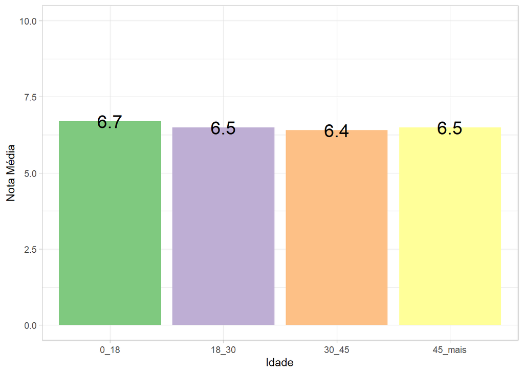

```r
imdb_avaliacoes |> filter(id_filme == "tt1014759") |>
select(contains("nota_media_idade")) |>
  pivot_longer(everything(),
               names_to = "nome",
               values_to = c("nota")) |> mutate(across(nome, str_remove_all, pattern = ".*\\idade_")) |> ggplot(aes(x = nome, y = nota, fill = nome, label = nota)) + geom_col(show.legend = FALSE) + labs(x = "Idade", y = "Nota Média") + scale_fill_brewer(palette = "Accent") + theme_light() + ylim(0,10) + geom_text(size = 6)
```